# Timeseries

### Exploratory analysis

Exploratory analyses are a continuation of understanding the dataset. Here I use the `scatterplotMatrix` function from the `car` package to see the densities of each variable (diagonal elements) and the pairwise plots for each set of variables (off diagonal elements). You can look at these bivariate relationships more closely by using the `boxplot` and `plot` functions.

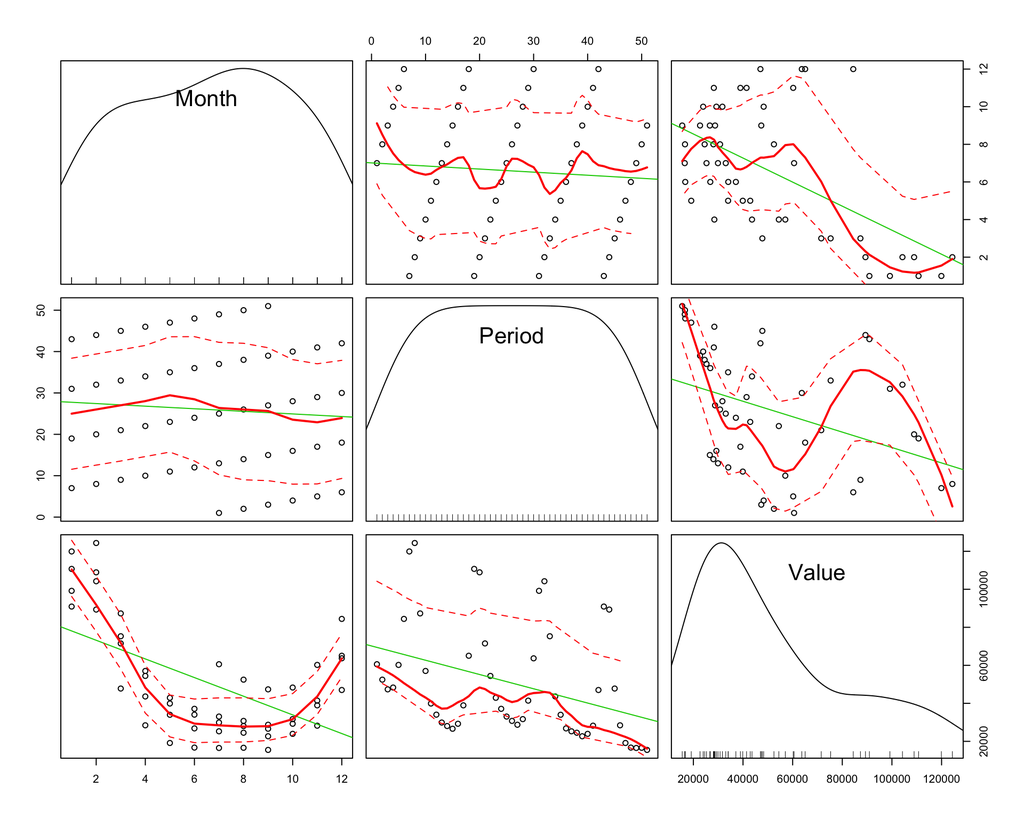

```r
scatterplotMatrix(unemp)
```

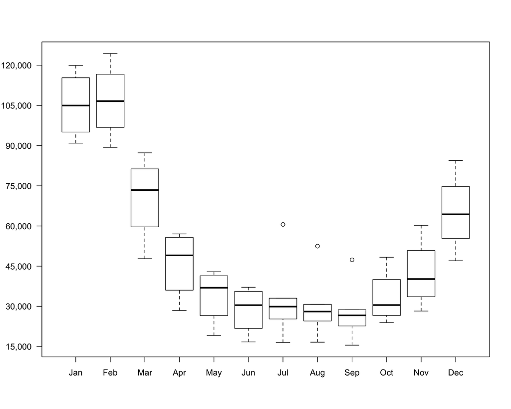

```r
boxplot(Value ~ Month, data = unemp, las = 1, yaxt = 'n')
yaxis.values <- seq(15000, 130000, 15000)
axis(side = 2, at = yaxis.values, labels = format(yaxis.values, big.mark = ','), las = 1)
```

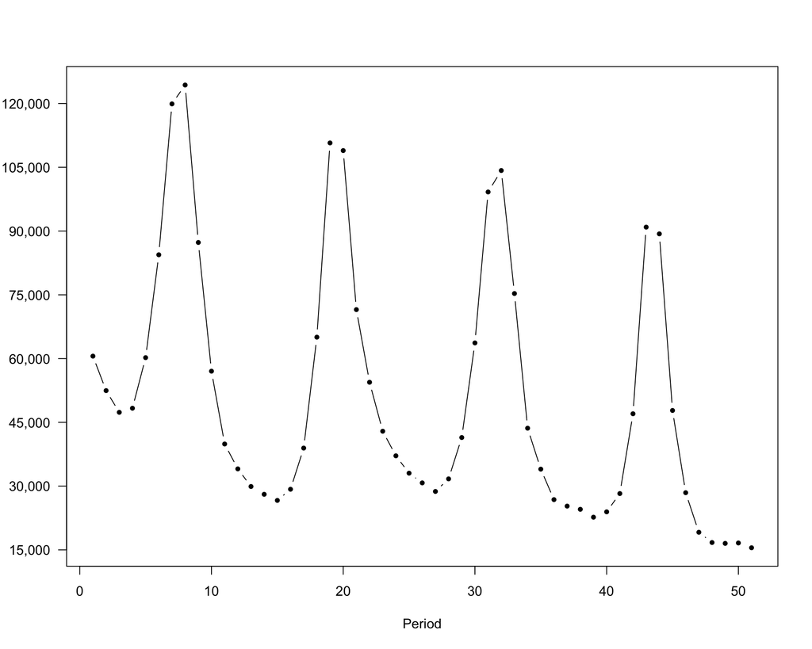

```r
plot(Value ~ Period, data = unemp, type = 'b', pch = 20, yaxt = 'n', ylab = NA)
axis(side = 2, at = yaxis.values, labels = format(yaxis.values, big.mark = ','), las = 1)
```

From the boxplots we could infer that unemployment tends to be higher in winter months. My guess would be that some people have seasonal work, such as summer construction jobs and holiday jobs, that result in generally lower unemployment during the summer.

### Motivating time series

The core idea of time series is that an observation is somehow influenced by previous observations, which is a violation of a key assumption in regression that errors (residuals) are independent. For example we can fit a linear model to predict unemployment given a month and the period and then check for autocorrelation of the residuals with the `durbinWatsonTest` function.

In this case we have seen that unemployment appears to have a seasonal trend and that the overall trend may be declining. Since I *know* the data have a monthly component, I check the residuals for autocorrelation and set the maximum lag to 12 (number of months in a year).

```r
fit <- lm(Value ~ Month + Period, data = unemp)
summary(fit)
```

```
##
## Call:
## lm(formula = Value ~ Month + Period, data = unemp)
##
## Residuals:
##    Min     1Q Median     3Q    Max
## -11841  -2714   1200   3609  10146
##
## Coefficients:
##              Estimate Std. Error t value Pr(>|t|)
## (Intercept)  70740.96    1688.38   41.90  < 2e-16 ***
## Month.L     -60358.95    2931.20  -20.59  < 2e-16 ***
## Month.Q      68867.14    2893.82   23.80  < 2e-16 ***
## Month.C       3773.07    2885.65    1.31  0.19889
## Month^4      -1915.75    2902.40   -0.66  0.51320
## Month^5      20137.44    2881.85    6.99  2.6e-08 ***
## Month^6     -10281.98    2872.49   -3.58  0.00096 ***
## Month^7       3347.38    2886.97    1.16  0.25349
## Month^8      -1659.81    2876.01   -0.58  0.56726
## Month^9       1133.02    2839.15    0.40  0.69208
## Month^10        -2.41    2802.71    0.00  0.99932
## Month^11      -877.29    2792.86   -0.31  0.75515
## Period        -723.29      56.60  -12.78  2.5e-15 ***
## ---
## Signif. codes:  0 '***' 0.001 '**' 0.01 '*' 0.05 '.' 0.1 ' ' 1
##
## Residual standard error: 5880 on 38 degrees of freedom
## Multiple R-squared:  0.97,   Adjusted R-squared:  0.961
## F-statistic:  104 on 12 and 38 DF,  p-value: <2e-16
```

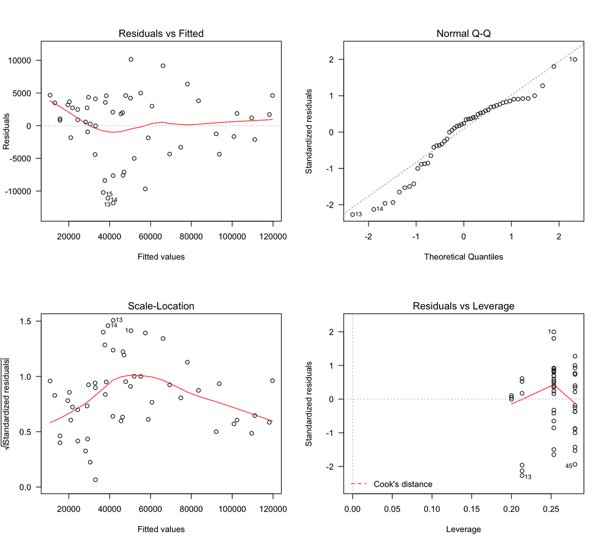

```r
par(mfrow = c(2, 2))
plot(fit, las = 1)
```

```r
par(mfrow = c(1, 1))
durbinWatsonTest(fit, max.lag = 12)
```

```
##  lag Autocorrelation D-W Statistic p-value
##    1         0.72833        0.4484   0.000
##    2         0.51697        0.8457   0.000
##    3         0.42985        1.0169   0.000
##    4         0.27939        1.3139   0.052
##    5         0.08781        1.6756   0.590
##    6        -0.09426        1.9942   0.396
##    7        -0.16235        2.0570   0.290
##    8        -0.26686        2.2354   0.082
##    9        -0.35267        2.3948   0.014
##   10        -0.29124        2.2503   0.042
##   11        -0.29100        2.2107   0.046
##   12        -0.39769        2.3695   0.212
##  Alternative hypothesis: rho[lag] != 0
```

### Decomposing/Fitting a time series model

ARIMA stands for auto-regressive integrated moving average, and are a class of models for general time series analysis. ARIMA models have three components: autoregressive terms, nonseasonal differences, and lagged forecast errors or the moving average. A time series model can have any or all of these terms.

| Term | Symbol | Description |
| --- | --- | --- |
| Autoregressive | $p$ | lagged terms of the time series itself |
| Differences | $d$ | order of differencing |
| Moving average | $q$ | lagged terms of the residuals |

We can use the `acf` and `pacf` to help us determine the terms to include in the model. The `acf` function plots the autocorrelation and the `pacf` plots the partial-autocorrelation. Compare the autocorrelation and partial-autocorrelation functions for unemployment (left) compared to random white noise (right).

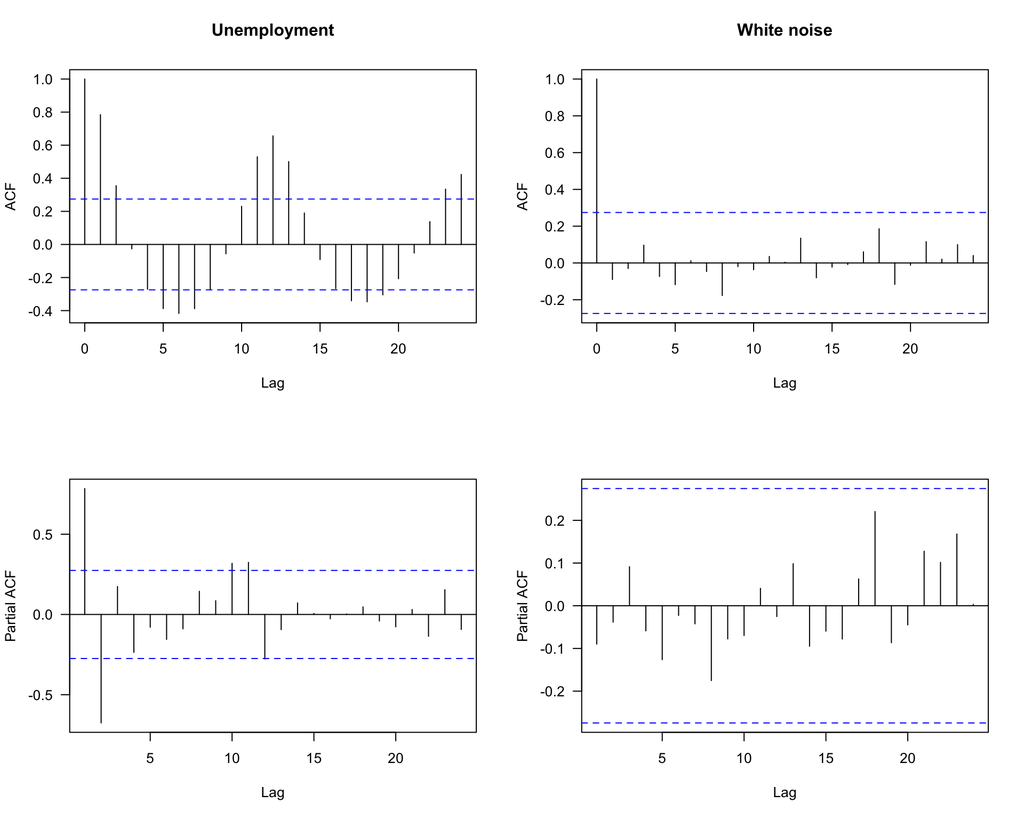

```r
x <- rnorm(n = 51, mean = 0, sd = 1)
par(mfrow = c(2, 2))
acf(unemp$Value, lag = 24, main = "Unemployment", las = 1)
acf(x, lag = 24, main = "White noise", las = 1)
pacf(unemp$Value, lag = 24, main = "", las = 1)
pacf(x, lag = 24, main = "", las = 1)
```

```r
par(mfrow = c(1, 1))
```

While it is important to look at these diagnostic plots, it is easy to fit a univariate time series model using the `auto.arima` function in the `forecast` package. This function compares several models and chooses the one that has the best optimization criteria (AIC, AICc, or BIC). The `auto.arima` function is pretty smart, but it is important to not let R do all of your thinking for you – you can use either `arima` or `Arima` to fit a time series model with fixed ordering terms.

```r
(myts <- ts(data = unemp$Value, start = c(1950, 7), frequency = 12))
```

```
##         Jan    Feb    Mar    Apr    May    Jun    Jul    Aug    Sep    Oct
## 1950                                            60572  52461  47357  48320
## 1951 119916 124350  87309  57035  39903  34053  29905  28068  26634  29259
## 1952 110728 108931  71517  54428  42911  37123  33044  30755  28742  31698
## 1953  99189 104240  75304  43622  33990  26819  25291  24538  22685  23945
## 1954  90920  89340  47792  28448  19139  16728  16523  16622  15499
##         Nov    Dec
## 1950  60219  84418
## 1951  38942  65036
## 1952  41427  63685
## 1953  28245  47017
## 1954
```

```r
(fit <- auto.arima(myts, trace = TRUE))
```

```
##
##  ARIMA(2,0,2)(1,1,1)[12] with drift         : 1e+20 *
##  ARIMA(0,0,0)(0,1,0)[12] with drift         : 571.9
##  ARIMA(1,0,0)(1,1,0)[12] with drift         : 534.3
##  ARIMA(0,0,1)(0,1,1)[12] with drift         : 1e+20
##  ARIMA(1,0,0)(0,1,0)[12] with drift         : 551.5
##  ARIMA(1,0,0)(1,1,1)[12] with drift         : 536.9
##  ARIMA(0,0,0)(1,1,0)[12] with drift         : 563.7
##  ARIMA(2,0,0)(1,1,0)[12] with drift         : 535.9
##  ARIMA(1,0,1)(1,1,0)[12] with drift         : 536.2
##  ARIMA(2,0,1)(1,1,0)[12] with drift         : 1e+20
##  ARIMA(1,0,0)(1,1,0)[12]                    : 768.6
##
##  Best model: ARIMA(1,0,0)(1,1,0)[12] with drift
```

```
## Series: myts
## ARIMA(1,0,0)(1,1,0)[12] with drift
##
## Coefficients:
##         ar1    sar1   drift
##       0.882  -0.824  -761.6
## s.e.  0.103   0.089   243.6
##
## sigma^2 estimated as 16187653:  log likelihood=-262.6
## AIC=533.1   AICc=534.3   BIC=539.8
```

### Forecasting (predicting) new observations:

```r
(pred <- forecast(fit, h = 128, level = 95))
```

```
##          Point Forecast     Lo 95    Hi 95
## Oct 1954        17626.6    9740.9  25512.3
## Nov 1954        25934.2   15419.8  36448.6
## Dec 1954        47167.3   34994.5  59340.0
## Jan 1955        83782.7   70462.0  97103.4
## Feb 1955        87348.0   73198.6 101497.4
## Mar 1955        55913.6   41151.8  70675.4
## Apr 1955        26149.2   10928.0  41370.3
## May 1955        16353.7     784.7  31922.8
## Jun 1955         9824.7   -6009.7  25659.1
## Jul 1955         8357.8   -7679.9  24395.6
## Aug 1955         7603.5   -8590.7  23797.6
## Sep 1955         5745.5  -10569.3  22060.3
## Oct 1955         7040.4   -9572.3  23653.1
## Nov 1955        11940.7   -4900.0  28781.4
## Dec 1955        31053.6   14037.7  48069.6
## Jan 1956        73596.0   56444.9  90747.0
## Feb 1956        72848.7   55593.3  90104.1
## Mar 1956        33014.5   15678.4  50350.6
## Apr 1956        11784.8   -5613.9  29183.5
## May 1956         2341.6  -15105.5  19788.7
## Jun 1956         -835.8  -18320.5  16649.0
## Jul 1956        -1300.3  -18814.3  16213.6
## Aug 1956        -1384.7  -18921.4  16152.0
## Sep 1956        -2666.3  -20220.6  14888.0
## Oct 1956         -711.0  -19775.8  18353.9
## Nov 1956         6975.1  -13186.6  27136.9
## Dec 1956        27815.6    6840.3  48790.8
## Jan 1957        65454.2   43867.3  87041.1
## Feb 1957        68246.3   46195.3  90297.2
## Mar 1957        35322.5   12917.3  57727.7
## Apr 1957         7045.0  -15631.9  29722.0
## May 1957        -2699.3  -25585.5  20186.8
## Jun 1957        -8649.2  -31696.7  14398.3
## Jul 1957        -9948.4  -33120.6  13223.9
## Aug 1957       -10592.5  -33861.3  12676.3
## Sep 1957       -12355.7  -35699.4  10987.9
## Oct 1957       -10950.6  -34630.0  12728.9
## Nov 1957        -5566.0  -29503.4  18371.4
## Dec 1957        13845.9  -10290.2  37982.0
```

[output cut: 74 more lines]

```
## Mar 1964       -35141.2  -72926.4   2643.9
## Apr 1964       -59412.5  -97272.6 -21552.5
## May 1964       -68987.6 -106905.8 -31069.4
## Jun 1964       -73362.3 -111325.7 -35398.9
## Jul 1964       -74188.3 -112186.9 -36189.8
## Aug 1964       -74515.4 -112541.2 -36489.6
## Sep 1964       -76005.9 -114052.9 -37958.9
## Oct 1964       -74288.9 -112799.7 -35778.0
## Nov 1964       -67596.2 -106464.1 -28728.4
## Dec 1964       -47372.7  -86516.0  -8229.4
## Jan 1965        -7993.2  -47349.3  31363.0
## Feb 1965        -6461.5  -45982.5  33059.4
## Mar 1965       -41843.9  -81492.5  -2195.2
## Apr 1965       -67617.5 -107365.2 -27869.7
## May 1965       -77256.2 -117080.9 -37431.6
```

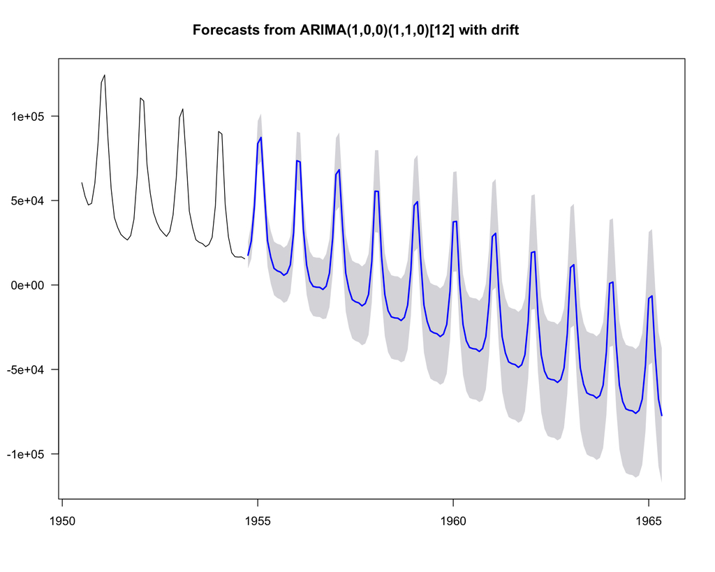

```r
plot(pred, las = 1)
```

Notice that the estimates become worse the further into the future we predict. This is because the uncertainty is compounded from each prediction to the next, since estimates of unemployment depend on previous values.